## PART B

```python
# Set the path Variables

# Filepath for the downloaded file
filepath = './17flowers.tgz'

# Filepath of the images folder after unzipping
extr_dir_path = r'./jpg'

# Folder Location for the images for testing our model, We can upload our test images in this folder
test_images_path = '../input/codex-botanical-research-data/Test Images'
```

# Loading the Dataset

```python
# We will use the wget command to download, wget stands for 'web get'.
# The dataset will be downloaded into the working directory of the notebook.

!wget https://www.robots.ox.ac.uk/~vgg/data/flowers/17/17flowers.tgz
```

```
--2022-07-08 06:45:55--  https://www.robots.ox.ac.uk/~vgg/data/flowers/17/17flowers.tgz
Resolving www.robots.ox.ac.uk (www.robots.ox.ac.uk)... 129.67.94.2
Connecting to www.robots.ox.ac.uk (www.robots.ox.ac.uk)|129.67.94.2|:443... connected.
HTTP request sent, awaiting response... 200 OK
Length: 60270631 (57M) [application/x-gzip]
Saving to: ‘17flowers.tgz.1’

17flowers.tgz.1     100%[===================>]  57.48M  20.0MB/s    in 2.9s

2022-07-08 06:45:58 (20.0 MB/s) - ‘17flowers.tgz.1’ saved [60270631/60270631]
```

```python
#Importing Required Libraries

import cv2
import os
import tensorflow as tf
import tarfile
from sklearn.model_selection import train_test_split
import matplotlib.pyplot as plt
import numpy as np
import pandas as pd

from tensorflow.keras.applications import VGG16
from tensorflow.keras import layers
from tensorflow.keras import optimizers
from tensorflow.keras import models
from tensorflow.keras.preprocessing.image import ImageDataGenerator
from keras.callbacks import ModelCheckpoint, EarlyStopping, ReduceLROnPlateau
from keras.models import load_model


from keras.preprocessing import image
from os import listdir
from os.path import isfile, join
import re
import matplotlib.image as mpimg
```

```python
# Using tarfile to unzip the downloaded tgz file
import tarfile
tar = tarfile.open(filepath,'r')
tar.extractall()
```

# EDA

### Understanding the Dataset:

There are 17 categories of flower in the dataset. Each flower has 80 consecutive images of a particular category. There are total of 1360 images.

We have got all the images in the jpg folder, we will now manually split the 80 images into 17 categories.

```python
# Classes Present in the Dataset
# classes = ['Daffodil','Snowdrop', 'Lily Valley', 'Bluebell','Crocus', 'Iris', 'Tigerlily', 'Tulip',
# 'Fritillary', 'Sunflower', 'Daisy', 'Colts Foot','Dandelalion', 'Cowslip', 'Buttercup', 'Windflower','Pansy']
```

```python
# Checking the total jpg files inside the extracted folder
# fnmatch function is used for filename pattern matching
import fnmatch

count = len(fnmatch.filter(os.listdir(extr_dir_path), '*.jpg'))
print('Total files:', count)
```

```
Total files: 1360
```

We are manually mapping class labels, that will be used at later stages while identifying images from the test folder.

```python
class_labels = {0: 'Daffodil', 1: 'Snowdrop', 2: 'Lily Valley', 3: 'Bluebell', 4: 'Crocus', 5: 'Iris', 6: 'Tigerlily', 7: 'Tulip', 8: 'fritillary', 9: 'Sunflower', 10: 'Daisy', 11: 'Colts Foot', 12: 'Dandelalion', 13: 'Cowslip', 14: 'Buttercup', 15: 'Windflower', 16: 'Pansy'}
```

There are 17 categories of flowers given in a particular order, In this step we will create an output variable that will store the category of each image, We will create a loop that will assign all the 80 consecutive images to a particular class and then other 80 to another class and so on, we are using numpy repeat function to achieve this.

We will use One-Hot Encoding for the conversion of categories as the model will work on numerical values.

```python
# Assigning Categories
classes = [ i for i in range(0,17) ]
y = np.repeat(classes, 80)

# Using one-hot encoding the 17 categories
y = tf.keras.utils.to_categorical(y, num_classes=17, dtype='float32')
```

```python
#Checking the output variable shape
y.shape
```

```
(1360, 17)
```

### Image Conversion

Converting images into numpy arrays is important, as the model accepts inputs in the form of numpy arrays

Also resizing the images to optimum size of 224x224, so that the model trains faster and VGG-16 works on 224x224 images

```python
# Resizing the images and storing them as numpy arrays
images = []
loc = os.path.expanduser(extr_dir_path)

for filename in sorted(os.listdir(loc)):

    img = cv2.imread(os.path.join(loc,filename))

    if img is not None:
        # Resizing the image to 224x224
        img = cv2.resize(img, dsize=(224, 224))
        # Changing the colour space to RGB
        img = cv2.cvtColor(img, cv2.COLOR_BGR2RGB)
        images.append(img)

images = np.asarray(images)
```

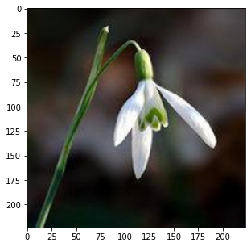

```python
# plotting one random image to see if data loaded correctly.
plt.figure(figsize = (5,5))
plt.imshow(images[103])
```

```python
# there are 1360 (i.e. 17*80) images in total, each with 224x224 pixels and 3 colour channels
images.shape
```

```
(1360, 224, 224, 3)
```

# Model Building

We will use existing VGG16 pre-trained model without the last output layer to train it on our images.

Below is the VGG16 architecture

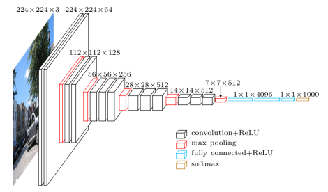

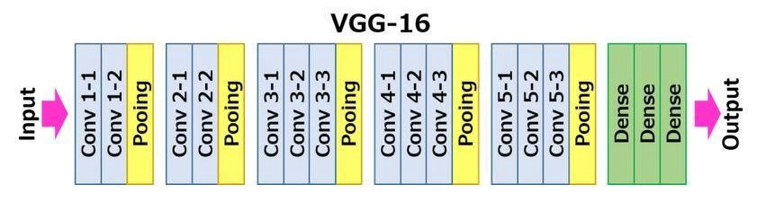

```python
# splitting data into training and validation data in a ratio of 80:20
X_train, X_val, y_train, y_val = train_test_split(images, y, test_size=0.2, random_state=0, shuffle=True)
```

#### Model Architecture

```python
# keeping VGG-16 as base layer (fixed), without its classifier at top
conv_base = VGG16(weights='imagenet',include_top=False, input_shape=(224, 224, 3))
conv_base.trainable = False

# building sequential model by adding Conv2D, MaxPool2D and other layers
model = models.Sequential()
model.add(conv_base)
model.add(layers.Conv2D(filters=64,kernel_size=(3,3),padding="same", activation="relu"))
model.add(layers.Conv2D(filters=64,kernel_size=(3,3),padding="same", activation="relu"))
model.add(layers.MaxPool2D(pool_size=(2,2),strides=(2,2)))
model.add(layers.Conv2D(filters=64,kernel_size=(3,3),padding="same", activation="relu"))
model.add(layers.Conv2D(filters=64,kernel_size=(3,3),padding="same", activation="relu"))
model.add(layers.MaxPool2D(pool_size=(2,2),strides=(2,2)))
model.add(layers.Flatten())
# dropping 20% randomly to prevent overfitting
model.add(layers.Dropout(0.2))
model.add(layers.Dense(512, activation='relu'))
model.add(layers.Dense(512, activation='relu'))
model.add(layers.Dense(17, activation='softmax'))
```

```python
# Model Summary
model.summary()
```

```
Model: "sequential_1"
_________________________________________________________________
Layer (type)                 Output Shape              Param #
=================================================================
vgg16 (Functional)           (None, 7, 7, 512)         14714688
_________________________________________________________________
conv2d_4 (Conv2D)            (None, 7, 7, 64)          294976
_________________________________________________________________
conv2d_5 (Conv2D)            (None, 7, 7, 64)          36928
_________________________________________________________________
max_pooling2d_2 (MaxPooling2 (None, 3, 3, 64)          0
_________________________________________________________________
conv2d_6 (Conv2D)            (None, 3, 3, 64)          36928
_________________________________________________________________
conv2d_7 (Conv2D)            (None, 3, 3, 64)          36928
_________________________________________________________________
max_pooling2d_3 (MaxPooling2 (None, 1, 1, 64)          0
_________________________________________________________________
flatten_1 (Flatten)          (None, 64)                0
_________________________________________________________________
dropout_1 (Dropout)          (None, 64)                0
_________________________________________________________________
dense_3 (Dense)              (None, 512)               33280
_________________________________________________________________
dense_4 (Dense)              (None, 512)               262656
_________________________________________________________________
dense_5 (Dense)              (None, 17)                8721
=================================================================
Total params: 15,425,105
Trainable params: 710,417
Non-trainable params: 14,714,688
_________________________________________________________________
```

```python
train_datagen = ImageDataGenerator (rescale=1./255,
                                    featurewise_std_normalization=True,
                                    zoom_range=0.2,
                                    rotation_range=90,
                                    width_shift_range=0.2,
                                    height_shift_range=0.2,
                                    horizontal_flip=True,
                                    fill_mode='nearest')

val_datagen = ImageDataGenerator (rescale=1./255, featurewise_std_normalization=True)

train_generator = train_datagen.flow(X_train, y_train, batch_size=32)

val_generator = val_datagen.flow(X_val, y_val, batch_size=32)
```

# Model Compilation and Evaluation

```python
# Creating checkpoint to sabe the best model
checkpoint = ModelCheckpoint("trained_model/17flowers_vgg.h5", monitor="val_loss", mode="min", save_best_only = True,
                             verbose=1)

# Stop training when a monitored metric has stopped improving
earlystop = EarlyStopping(monitor = 'val_loss',  min_delta = 0,  patience = 3, verbose = 1, restore_best_weights = True)

# Reduce learning rate when a metric has stopped improving
reduce_lr = ReduceLROnPlateau(monitor = 'val_loss', factor = 0.2, patience = 3, verbose = 1, min_delta = 0.0001)

callbacks = [checkpoint, reduce_lr]

batch_size = 32
ntrain = len(X_train)
nval = len(X_val)

# choosing Adam optimizer, also defining loss function and evaluation metrics
model.compile(
    optimizer=tf.keras.optimizers.Adam(epsilon=0.00001),
    loss='categorical_crossentropy',
    metrics=['accuracy']
)

# fitting the model over 50 epochs here
history = model.fit_generator(
    train_generator,
    validation_data=val_generator,
    epochs=50,
    callbacks = callbacks,
    steps_per_epoch = ntrain // batch_size,
    validation_steps = nval // batch_size
)
```

```
Epoch 00001: val_loss improved from inf to 2.67261, saving model to trained_model/17flowers_vgg.h5

Epoch 00002: val_loss improved from 2.67261 to 1.95304, saving model to trained_model/17flowers_vgg.h5

Epoch 00003: val_loss improved from 1.95304 to 1.66616, saving model to trained_model/17flowers_vgg.h5

Epoch 00004: val_loss improved from 1.66616 to 1.60752, saving model to trained_model/17flowers_vgg.h5

Epoch 00005: val_loss improved from 1.60752 to 1.43783, saving model to trained_model/17flowers_vgg.h5

Epoch 00006: val_loss improved from 1.43783 to 1.33311, saving model to trained_model/17flowers_vgg.h5

Epoch 00007: val_loss improved from 1.33311 to 1.23709, saving model to trained_model/17flowers_vgg.h5

Epoch 00008: val_loss improved from 1.23709 to 1.19502, saving model to trained_model/17flowers_vgg.h5

Epoch 00009: val_loss improved from 1.19502 to 1.06642, saving model to trained_model/17flowers_vgg.h5

Epoch 00010: val_loss improved from 1.06642 to 1.03713, saving model to trained_model/17flowers_vgg.h5

Epoch 00011: val_loss improved from 1.03713 to 1.03615, saving model to trained_model/17flowers_vgg.h5

Epoch 00012: val_loss did not improve from 1.03615

Epoch 00013: val_loss did not improve from 1.03615

Epoch 00014: val_loss improved from 1.03615 to 0.94077, saving model to trained_model/17flowers_vgg.h5

Epoch 00015: val_loss improved from 0.94077 to 0.76849, saving model to trained_model/17flowers_vgg.h5

Epoch 00016: val_loss did not improve from 0.76849

Epoch 00017: val_loss improved from 0.76849 to 0.76258, saving model to trained_model/17flowers_vgg.h5

Epoch 00018: val_loss did not improve from 0.76258

Epoch 00019: val_loss improved from 0.76258 to 0.69398, saving model to trained_model/17flowers_vgg.h5

Epoch 00020: val_loss did not improve from 0.69398

```

[output cut: 60 more lines]

```
Epoch 00045: val_loss did not improve from 0.60875

Epoch 00045: ReduceLROnPlateau reducing learning rate to 1.2800001059076749e-08.

Epoch 00046: val_loss did not improve from 0.60875

Epoch 00047: val_loss did not improve from 0.60875

Epoch 00048: val_loss did not improve from 0.60875

Epoch 00048: ReduceLROnPlateau reducing learning rate to 2.5600002118153498e-09.

Epoch 00049: val_loss did not improve from 0.60875

Epoch 00050: val_loss did not improve from 0.60875
```

```python
# Loading the Model
model = load_model('trained_model/17flowers_vgg.h5')
```

#### Loss and Accuracy Graphs

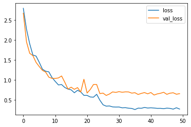

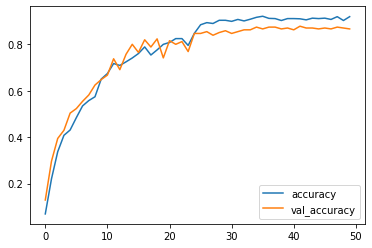

```python
history_frame = pd.DataFrame(history.history)
history_frame.loc[:, ['loss', 'val_loss']].plot()
history_frame.loc[:, ['accuracy', 'val_accuracy']].plot();
```

# Prediction of Uploaded Images

```
( 1 )
Filename : daisy_3.png
```

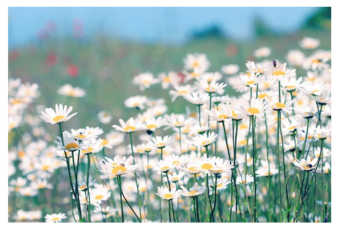

```
Predicted Class of the above image is :  Bluebell.

( 2 )
Filename : colts foot_1.png
```

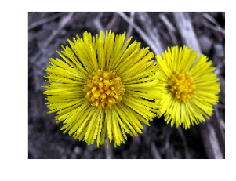

```
Predicted Class of the above image is :  Colts Foot.

( 3 )
Filename : rose_1.PNG
```

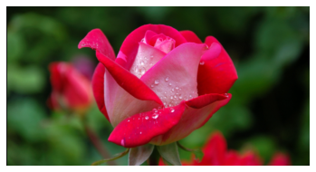

```
Predicted Class of the above image is :  Crocus.

( 4 )
Filename : sunflower_3.png
```

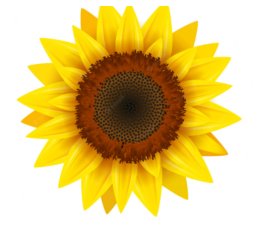

```
Predicted Class of the above image is :  Sunflower.

( 5 )
Filename : dog_1.PNG
```

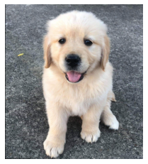

```
Predicted Class of the above image is :  Sunflower.

( 6 )
Filename : pansy_1.png
```

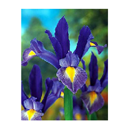

```
Predicted Class of the above image is :  Tulip.

( 7 )
Filename : sunflower_2.png
```

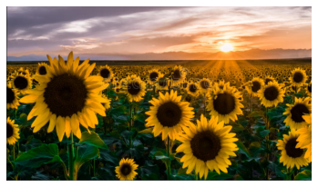

```
Predicted Class of the above image is :  Sunflower.

( 8 )
Filename : daisy_2.png
```

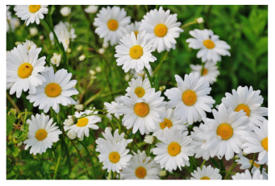

```
Predicted Class of the above image is :  Daisy.

( 9 )
Filename : daisy_1.png
```

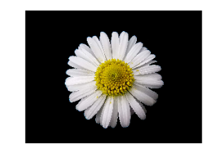

```
Predicted Class of the above image is :  Daisy.

( 10 )
Filename : bluebell_1.png
```

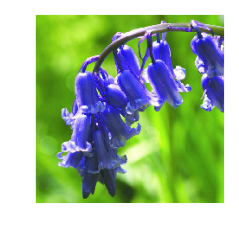

```
Predicted Class of the above image is :  Bluebell.

( 11 )
Filename : sunflower_1.png
```

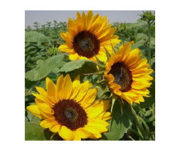

```
Predicted Class of the above image is :  Sunflower.
```

```python
# Function to read images from the given path and predict the image class
def imagepredict(path):
    img=mpimg.imread(path)
    plt.imshow(img)
    plt.axis('off')
    plt.show()

    # prediction
    img = image.load_img(path, target_size=(224, 224))
    x = image.img_to_array(img)
    x = np.expand_dims(x, axis=0)
    x = x.astype('float32')/255
    pred = np.argmax(model.predict(x))
    print("Predicted Class of the above image is :  {}.".format(class_labels[pred]))



# Printing the Prediction Results
file_names = [f for f in listdir(test_images_path) if isfile(join(test_images_path, f))]
for i in range(0, len(file_names)):
    file = test_images_path + "/" + file_names[i]
    print("\n(",i+1,")")
    print("Filename : {}".format(file_names[i]))
    imagepredict(file)
```